# Assessing Quadratic for Groove Locations

## Hamby44

We will first take a look at the Hamby 44 Rescan data. There are lists of groove predictions (using Eric’s smoothing method “rollapply”) and groove manual identifications (done by Dr. Hofmann).

`cccata`, within the Hamby 44 Rescan data, contains x-y-value formatted data.

```
## # A tibble: 6 x 10
## # Groups:   PARTITION_ID [1]
##   source          barrel bullet land  PARTITION_ID x3p   crosscuts ccdata
##   <chr>           <chr>  <chr>  <chr>        <dbl> <lis>     <dbl> <list>
## 1 Barrel 4/Bulle… Barre… Bulle… Land…         1.00 <S3:…      50.0 <data.…
## 2 Barrel 10/Bull… Barre… Bulle… Land…         1.00 <S3:…     125   <data.…
## 3 Barrel 2/Bulle… Barre… Bulle… Land…         1.00 <S3:…     150   <data.…
## 4 Unknowns/Bulle… Unkno… Bulle… Land…         1.00 <S3:…     125   <data.…
## 5 Barrel 10/Bull… Barre… Bulle… Land…         1.00 <S3:…     250   <data.…
## 6 Barrel 6/Bulle… Barre… Bulle… Land…         1.00 <S3:…     150   <data.…
## # ... with 2 more variables: grooves_pred <list>, grooves <list>
```

There are a few changes we want to make to the `hamby44` data before we fit things.

The first is that there are a few lands that are `NA` values, so we just need to filter those out before we can do anything else. It looks like it only happens in two cases, so we are still left with 208 viable lands.

```r
hamby44 <- hamby44 %>% filter(!is.na(crosscuts))
```

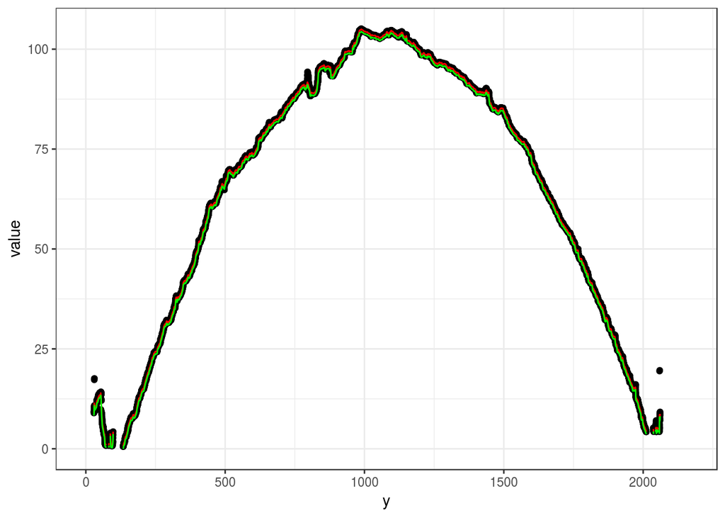

Now, because one of the things we want to be able to do is look at the residuals from the robust linear model we will fit in the `get_grooves_quadratic` function, we will fit the robust linear model and compute the residuals, in order to have them for future assessment purposes. **Note here: If we change what settings we are using on the RLM, we need to RERUN this to make sure we are getting the correct residuals.**

Note that we will do this with the `value_std` column from `ccdata_avg`, so we will need to make sure we use `value_std` when we actually run the function later. It calls `value` as it is defined. *Maybe add a parameter to the function that lets you define what the value column is called.*

Now that we have made all the changes we need to our data, we can begin exploring the `get_grooves_quadratic` function as it is in the bulletr package, and defined below (with the exception that value is now value_std):

```r
get_grooves_quadratic <- function(bullet, adjust) {
  lm0 <- MASS::rlm(value_std~poly(y,2), data=bullet, maxit=100)
  bullet$pred <- predict(lm0, newdata=bullet)

  bullet$absresid <- with(bullet, abs(value_std-pred))
  bullet$absresid90 <- with(
    bullet, absresid>4*median(bullet$absresid, na.rm=TRUE))

  groove <- range(filter(bullet, !absresid90)$y) + c(adjust, -adjust)

  plot <- bullet %>% ggplot(aes(x = y, y = value_std)) + geom_line(size = .5) + theme_bw() +
    geom_vline(xintercept=groove[1], colour = "blue") +
    geom_vline(xintercept=groove[2], colour = "blue")

  return(list(groove = groove, plot = plot))
}
```

We can fit the function, and here for simplicity of organization, our output will be just the actual groove values, rather than the groove and the plot that the function output.

```r
hamby44 <- hamby44 %>% mutate(grooves_quad_pred = purrr::map(ccdata_avg, .f = function(x){
  get_grooves_quadratic(bullet = x, adjust = 0)$groove
}))
```

Now that we have fitted the function, we can check to see how far away things are from the manually identified grooves. We will calculate four columns: `rollapply_left_diff`, `rollapply_right_diff`, `quadratic_left_diff`, and `quadratic_right_diff`. This gives us the differences between the fits using rollapply and the manual ID’s, as well as the fits using the quadratic and the manual ID’s. Note that we will expect a lot of 0 values in the rollapply ones, as if the rollapply is doing a good job of identifying, the manual identification would have kept it at that spot exactly.

The addition of these columns can be seen below (for the first few rows):

```
## # A tibble: 6 x 17
## # Groups:   PARTITION_ID [1]
##   source          barrel bullet land  PARTITION_ID x3p   crosscuts ccdata
##   <chr>           <chr>  <chr>  <chr>        <dbl> <lis>     <dbl> <list>
## 1 Barrel 4/Bulle… Barre… Bulle… Land…         1.00 <S3:…      50.0 <data.…
## 2 Barrel 10/Bull… Barre… Bulle… Land…         1.00 <S3:…     125   <data.…
## 3 Barrel 2/Bulle… Barre… Bulle… Land…         1.00 <S3:…     150   <data.…
## 4 Unknowns/Bulle… Unkno… Bulle… Land…         1.00 <S3:…     125   <data.…
## 5 Barrel 10/Bull… Barre… Bulle… Land…         1.00 <S3:…     250   <data.…
## 6 Barrel 6/Bulle… Barre… Bulle… Land…         1.00 <S3:…     150   <data.…
## # ... with 9 more variables: grooves_pred <list>, grooves <list>,
## #   ccdata_avg <list>, ccdata_w_resid <list>, grooves_quad_pred <list>,
## #   rollapply_left_diff <dbl>, rollapply_right_diff <dbl>,
## #   quadratic_left_diff <dbl>, quadratic_right_diff <dbl>
```

We can look at some preliminary comparisons of these two methods to see if the original quadratic is even doing much better than the rollapply.

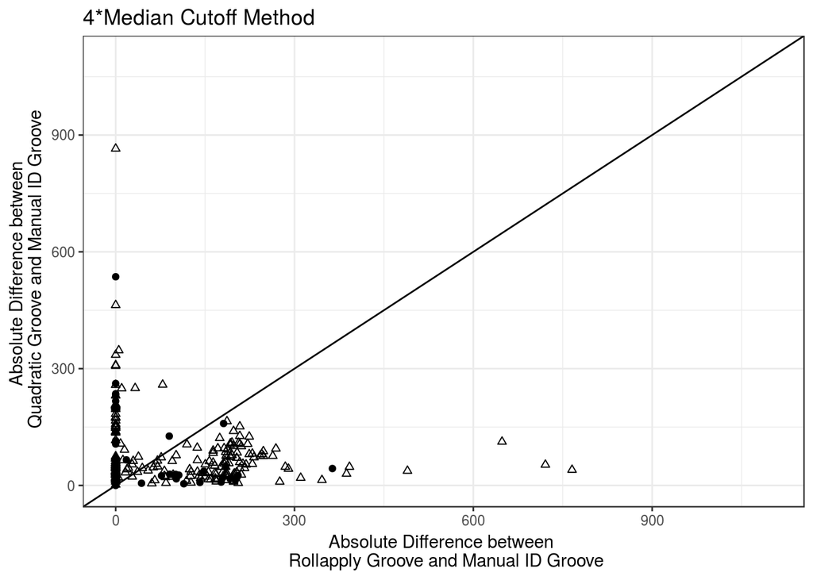

What we will try next is looking at fitting a quadratic, finding the signs of the lags of the residuals, and looking for where the proportion of negative to positive signs change.  
**Note: This proportion thing did not go well. Looking at the patterns of the residuals, there is not an obvious shift in proportion. It zig-zags around quite a bit, so it looks like this will not be helpful.**

Now, we will try another method for the cutoff value of the residuals. Instead of cutting off at 4 times the median of the absolute residuals, we will instead divide the residuals by their relative height, and take the range of residuals that are non-positive. That is, we expect both positive and negative residuals on the actual curve of the bullet, so we can remove any points that have that positive residuals and take the range of what remains. (Sidenote: This may require more messing around with the adjust, in case it is cutting off too far out or too far in.)

This new function, `get_grooves_quadratic_pos_resid` (I need a more succinct name) is defined below:

```r
get_grooves_quadratic_pos_resid <- function(bullet, adjust) {
  lm0 <- MASS::rlm(value_std~poly(y,2), data=bullet, maxit=100)
  bullet$pred <- predict(lm0, newdata=bullet)

  #bullet$absresid <- with(bullet, abs(value-pred))
  bullet$resid <- with(bullet, value_std-pred)
  #bullet$absresid_div <- with(bullet, absresid/value)
  bullet$resid_div <- with(bullet, resid/value_std)
  #bullet %>% ggplot() + geom_point(aes(x = y, y = resid)) + theme_bw()
  #bullet %>% ggplot() + geom_point(aes(x = y, y = resid_div)) + theme_bw()

  bullet$resid_cutoff <- with (bullet, resid_div > 0)
  groove <- range(filter(bullet, !resid_cutoff)$y) + c(adjust, -adjust)

  plot <- bullet %>% ggplot(aes(x = y, y = value_std)) + geom_line(size = .5) + theme_bw() +
    geom_vline(xintercept=groove[1], colour = "blue") +
    geom_vline(xintercept=groove[2], colour = "blue")

  return(list(groove = groove, plot = plot))
}
```

We will now apply this to the `ccdata_avg` set again to get our predicted grooves with this new method.

Additionally, we can calculate differences between these and the Manually ID’d grooves, and plot the comparison between this and rollapply.

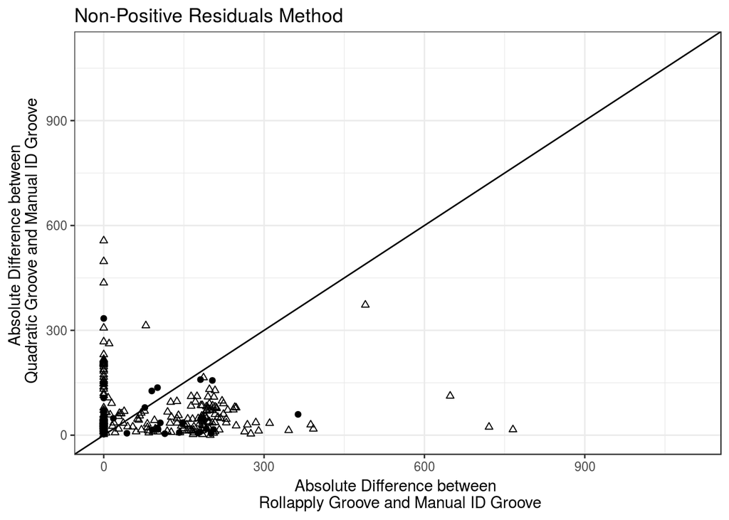

Additionally, we can plot the difference between the two quadratic methods to see if one is better than the other.

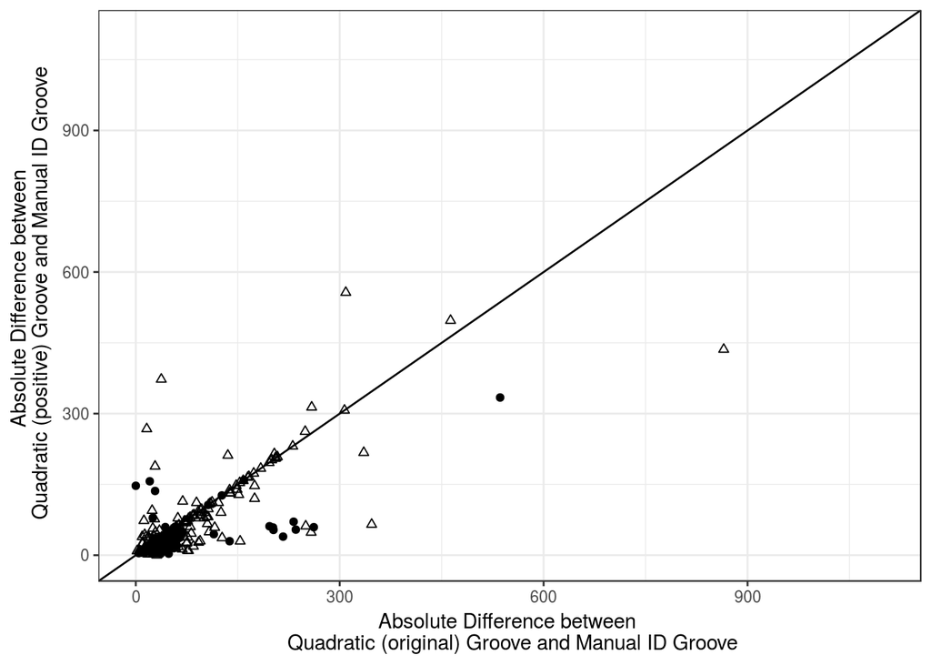

Now, we will look at the sums of residuals between the manually ID’d grooves and the grooves ID’d by the quadratic method.

We can explore these differences before we actually fit the linear model including this to see if we can see a pattern. We will do this first for the original 4 times median method.

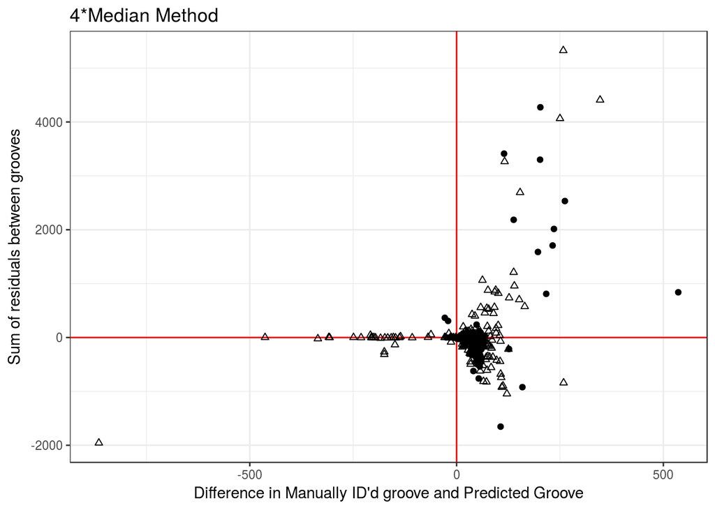

The way this plot is set up, we have that the more positive the difference, the further in the manually ID’d groove is towards the center. This means that we are more concerned with positive values along the x-axis (i.e., manual identification puts it further in) than negative values (i.e., we may be losing a little more data than we need, but there aren’t grooves inside of where the prediction falls).

Let’s also take a look at this for the new positive residuals cutoff.

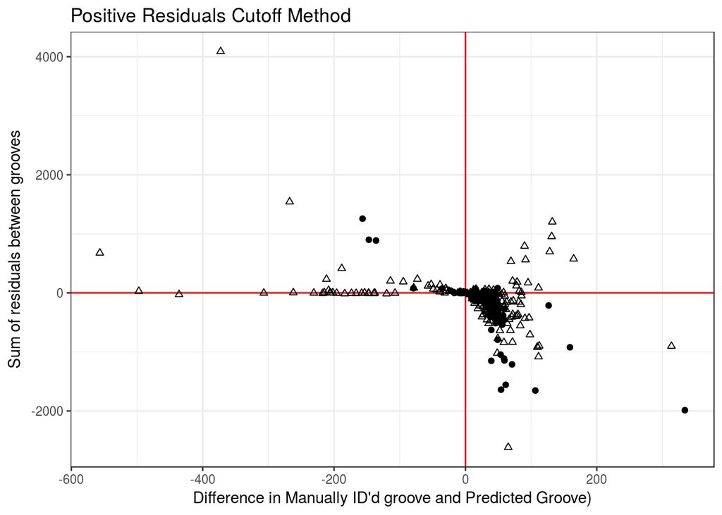

Next we will consider fitting a linear model to fit the difference between manual and predicted grooves based on the sum of the residuals that occur between them and the depth (how far away they are from the center). We will calculate this “center” based on the median of the y values. *Note: something to consider if we are getting wonky results, are all the y values there even if there isn’t a value, or where there is missing data are we also missing the y values? This could throw off the median of y*.

The first thing we have to do is create a data frame with all this info!

```
##   is_right_groove   pred_diff   resid_sum
## 1               1  -11.483873   -1.186883
## 2               1   20.987740 -137.961293
## 3               1  104.392603   36.292801
## 4               1 -308.955000    2.574732
## 5               1    9.503696    4.176176
## 6               1   44.416014  400.100803
```

```
##
## Call:
## lm(formula = pred_diff ~ is_right_groove + resid_sum, data = pred_assess)
##
## Residuals:
##     Min      1Q  Median      3Q     Max
## -782.30  -10.22    6.65   29.48  440.03
##
## Coefficients:
##                   Estimate Std. Error t value Pr(>|t|)
## (Intercept)      53.460827   5.882983   9.087  < 2e-16 ***
## is_right_groove -36.982047   8.327603  -4.441 1.15e-05 ***
## resid_sum         0.050667   0.006284   8.062 8.17e-15 ***
## ---
## Signif. codes:  0 '***' 0.001 '**' 0.01 '*' 0.05 '.' 0.1 ' ' 1
##
## Residual standard error: 84.83 on 413 degrees of freedom
## Multiple R-squared:  0.1648, Adjusted R-squared:  0.1607
## F-statistic: 40.73 on 2 and 413 DF,  p-value: < 2.2e-16
```

### Notes

If it doesn’t do well, try one of the other methods within rlm (“MM”, “model.frame”, etc. the default is “M”).

Ideas: dividing by absolute height (may have to standardize down to zero), dividing by relative closeness to edge of the overall bullet land,

Fitting several different shapes (polynomial of order 2, polynomial of order 4 - maybe not polynomial of order 3 because whichever shoulder is higher will ‘take over’.) Polynomial order 3 doesn’t converge? does converge?

When we do these things, want to check how far away they are from the manually ID’d ones. In some cases, the manual ID is going to be all the way at the edge, not adjusted after automatically put there.

Looking at the residuals, if we rollapply across and see what the proportion of the sign is (where sign is where the difference between residual i and residual i-1), where does that proportion start evening out? - *No, it does not. Looking at it, it is all over the place (even with a huge window)*

Depth - from the median of the y’s all the way to the furthest data point we have. If we do a rollapply on the residuals after, make sure that we average across the residuals first, because there are 9 crosscuts involved.

One option could be to sum the residuals between where the rollapply location is and where the quadratic location is. Maybe use a linear model to model the difference in the two (the y) by the residuals and the depth (depth of 0 is the median of the y’s, so )

Trimming and continuing until the rlm parameters stop changing. Splice off 1/2 a percent (highest 1/2 percent of residuals each time) each time and compare what parameters we are getting in the rlm